# Ford GoBikes Explanatory Analysis

## by George Kariuki

## Investigation Overview

The overarching goal of this project was to ascertain the factors affecting the duration of trips logged in from users who were using the bikes.

The main focus was on how age affected the duration. Age was also coupled with User Type which provided a rather interesting observation worth documenting.

## Dataset Overview

The data consisted of 183,412 records with 16 features. The features include duration_sec, start_time, end_time, start_station_id,start_station_name, start_station_latitude,start_station_longitude, end_station_id, end_station_name,end_station_latitude, end_station_longitude, bike_id, user_type,member_birth_year, member_gender, bike_share_for_all_trip. 9 features are numeric, 2 features are datetime objects, 1 boolean based feature and 4 objects based features. No records were dropped - the data was clean without any duplicates.

## Distribution of Duration in Seconds

The Ford GoBike dataset provides data on the duration of each trip logged in by a user. This duration was measured in seconds and ranged from 61 second trips all the way to 85444 seconds - this is approximately a whole day. Due to it's large size, zooming in to a small space through the use of limits and using a logarithmic scale, we get a unimodal curve showing the distribution of the duration feature.

We expect that age should be a factor contributing to the bell shaped curve of the duration.

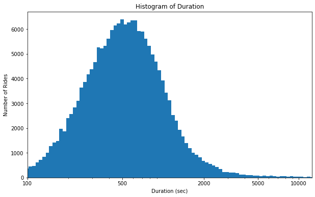

## Duration versus Age

Age was plotted against the log of Duration (sec), and a heatmap was produced. A key highlight of the heatmap revealed that the most active participants were those in the age group of 20 - 40. This age group were concentrated in the lower left regions of the heatmap meaning they were not riding the bikes for very long. We might have expected the age group to log longer periods but this was not the case.

It is interesting to note the 60-80 group have logging enough hours to be featured in the heatmap despite their ages. This means there is quite an active older generation in the area.

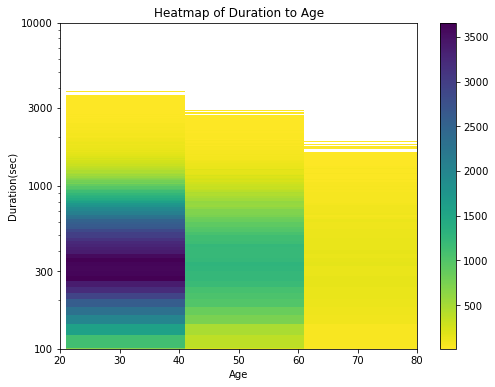

## Age and Duration by User Type

An interesting aspect as seen when age and duration was plotted against User Type. User Type consists of two categories - Subscribers - those with an active and inactive subscription, and Customers - those who haven't subscribed to the Ford GoBikes.

The multivariate plots revealed that although subscribers are the largest group as compared to the customers, customers logged more time with the bikes than the subscribers. Subsribers dominated the lower regions across the chart clocking in lower times with the bikes.

Subscriber ages spread quite evenly across the charts while customers dominated in the 20 - 50 region. Customers were sparce in the 50 - 80 region.

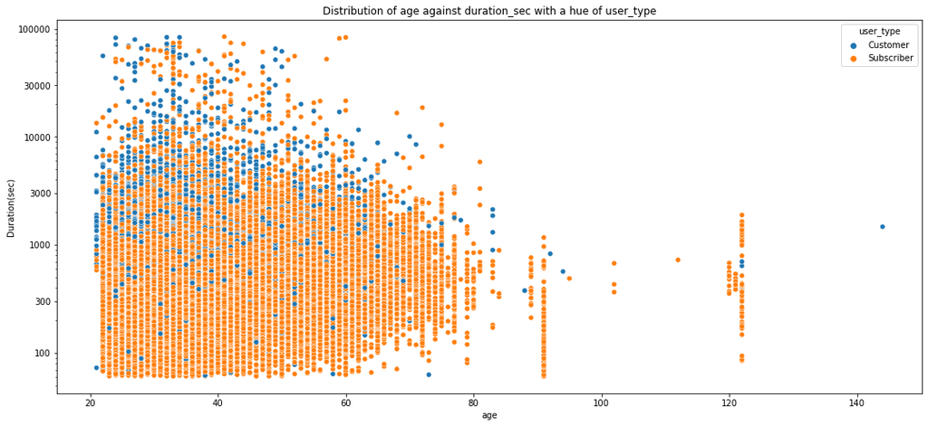